# Risk Factor Analysis

## Outcome Variable

**Outcome Variable:** whz

## Predictor Variables

**Intervention Variable:** rain_quartile

**Adjustment Set:**

unadjusted

## Stratifying Variables

The analysis was stratified on these variable(s):

- studyid
- country
- agecat

## Data Summary

| studyid | country | agecat | rain_quartile | n_cell | n |
| --- | --- | --- | --- | --- | --- |
| CMC-V-BCS-2002 | India | Birth | 1 | 17 | 86 |
| CMC-V-BCS-2002 | India | Birth | 2 | 22 | 86 |
| CMC-V-BCS-2002 | India | Birth | 3 | 28 | 86 |
| CMC-V-BCS-2002 | India | Birth | 4 | 19 | 86 |
| CMC-V-BCS-2002 | India | 6 months | 1 | 102 | 368 |
| CMC-V-BCS-2002 | India | 6 months | 2 | 109 | 368 |
| CMC-V-BCS-2002 | India | 6 months | 3 | 97 | 368 |
| CMC-V-BCS-2002 | India | 6 months | 4 | 60 | 368 |
| CMC-V-BCS-2002 | India | 24 months | 1 | 101 | 372 |
| CMC-V-BCS-2002 | India | 24 months | 2 | 99 | 372 |
| CMC-V-BCS-2002 | India | 24 months | 3 | 117 | 372 |
| CMC-V-BCS-2002 | India | 24 months | 4 | 55 | 372 |
| CMIN | Bangladesh | Birth | 1 | 4 | 19 |
| CMIN | Bangladesh | Birth | 2 | 5 | 19 |
| CMIN | Bangladesh | Birth | 3 | 5 | 19 |
| CMIN | Bangladesh | Birth | 4 | 5 | 19 |
| CMIN | Bangladesh | 6 months | 1 | 50 | 243 |
| CMIN | Bangladesh | 6 months | 2 | 62 | 243 |
| CMIN | Bangladesh | 6 months | 3 | 70 | 243 |
| CMIN | Bangladesh | 6 months | 4 | 61 | 243 |
| CMIN | Bangladesh | 24 months | 1 | 79 | 243 |
| CMIN | Bangladesh | 24 months | 2 | 69 | 243 |
| CMIN | Bangladesh | 24 months | 3 | 58 | 243 |
| CMIN | Bangladesh | 24 months | 4 | 37 | 243 |
| CONTENT | Peru | Birth | 1 | 0 | 2 |
| CONTENT | Peru | Birth | 2 | 2 | 2 |
| CONTENT | Peru | Birth | 3 | 0 | 2 |
| CONTENT | Peru | Birth | 4 | 0 | 2 |
| CONTENT | Peru | 6 months | 1 | 62 | 215 |
| CONTENT | Peru | 6 months | 2 | 32 | 215 |

[output cut: 214 more lines]

The following strata were considered:

- studyid: CMC-V-BCS-2002, country: India, agecat: 24 months
- studyid: CMC-V-BCS-2002, country: India, agecat: 6 months
- studyid: CMC-V-BCS-2002, country: India, agecat: Birth
- studyid: CMIN, country: Bangladesh, agecat: 24 months
- studyid: CMIN, country: Bangladesh, agecat: 6 months
- studyid: CMIN, country: Bangladesh, agecat: Birth
- studyid: CONTENT, country: Peru, agecat: 24 months
- studyid: CONTENT, country: Peru, agecat: 6 months
- studyid: CONTENT, country: Peru, agecat: Birth
- studyid: EE, country: Pakistan, agecat: 24 months
- studyid: EE, country: Pakistan, agecat: 6 months
- studyid: EE, country: Pakistan, agecat: Birth
- studyid: GMS-Nepal, country: Nepal, agecat: 24 months
- studyid: GMS-Nepal, country: Nepal, agecat: 6 months
- studyid: GMS-Nepal, country: Nepal, agecat: Birth
- studyid: Guatemala BSC, country: Guatemala, agecat: 6 months
- studyid: IRC, country: India, agecat: 24 months
- studyid: IRC, country: India, agecat: 6 months
- studyid: IRC, country: India, agecat: Birth
- studyid: Keneba, country: Gambia, agecat: 24 months
- studyid: Keneba, country: Gambia, agecat: 6 months
- studyid: Keneba, country: Gambia, agecat: Birth
- studyid: LCNI-5, country: Malawi, agecat: 24 months
- studyid: LCNI-5, country: Malawi, agecat: 6 months
- studyid: MAL-ED, country: Bangladesh, agecat: 24 months
- studyid: MAL-ED, country: Bangladesh, agecat: 6 months
- studyid: MAL-ED, country: Bangladesh, agecat: Birth
- studyid: MAL-ED, country: Brazil, agecat: 24 months
- studyid: MAL-ED, country: Brazil, agecat: 6 months
- studyid: MAL-ED, country: Brazil, agecat: Birth
- studyid: MAL-ED, country: India, agecat: 24 months
- studyid: MAL-ED, country: India, agecat: 6 months
- studyid: MAL-ED, country: India, agecat: Birth
- studyid: MAL-ED, country: Nepal, agecat: 24 months
- studyid: MAL-ED, country: Nepal, agecat: 6 months
- studyid: MAL-ED, country: Nepal, agecat: Birth
- studyid: MAL-ED, country: Peru, agecat: 24 months
- studyid: MAL-ED, country: Peru, agecat: 6 months
- studyid: MAL-ED, country: Peru, agecat: Birth
- studyid: MAL-ED, country: South Africa, agecat: 24 months
- studyid: MAL-ED, country: South Africa, agecat: 6 months
- studyid: MAL-ED, country: South Africa, agecat: Birth
- studyid: MAL-ED, country: Tanzania, agecat: 24 months
- studyid: MAL-ED, country: Tanzania, agecat: 6 months
- studyid: MAL-ED, country: Tanzania, agecat: Birth
- studyid: PROBIT, country: Belarus, agecat: 24 months
- studyid: PROBIT, country: Belarus, agecat: 6 months
- studyid: PROBIT, country: Belarus, agecat: Birth
- studyid: PROVIDE, country: Bangladesh, agecat: 24 months
- studyid: PROVIDE, country: Bangladesh, agecat: 6 months
- studyid: PROVIDE, country: Bangladesh, agecat: Birth
- studyid: ResPak, country: Pakistan, agecat: 6 months
- studyid: ResPak, country: Pakistan, agecat: Birth
- studyid: SAS-CompFeed, country: India, agecat: 6 months
- studyid: SAS-CompFeed, country: India, agecat: Birth
- studyid: SAS-FoodSuppl, country: India, agecat: 6 months
- studyid: TanzaniaChild2, country: Tanzania, agecat: 24 months
- studyid: TanzaniaChild2, country: Tanzania, agecat: 6 months
- studyid: ZVITAMBO, country: Zimbabwe, agecat: 24 months
- studyid: ZVITAMBO, country: Zimbabwe, agecat: 6 months
- studyid: ZVITAMBO, country: Zimbabwe, agecat: Birth

### Dropped Strata

Some strata were dropped due to rare outcomes:

- studyid: CMIN, country: Bangladesh, agecat: Birth
- studyid: CONTENT, country: Peru, agecat: Birth
- studyid: EE, country: Pakistan, agecat: Birth
- studyid: EE, country: Pakistan, agecat: 6 months
- studyid: EE, country: Pakistan, agecat: 24 months
- studyid: GMS-Nepal, country: Nepal, agecat: Birth
- studyid: GMS-Nepal, country: Nepal, agecat: 6 months
- studyid: GMS-Nepal, country: Nepal, agecat: 24 months
- studyid: ResPak, country: Pakistan, agecat: Birth
- studyid: TanzaniaChild2, country: Tanzania, agecat: 24 months

## Methods Detail

We’re interested in the causal parameters $E[Y_a]$ for all values of $a \in \mathcal{A}$. These parameters represent the mean outcome if, possibly contrary to fact, we intervened to set all units to have $A=a$. Under the randomization and positivity assumptions, these are identified by the statistical parameters $\psi_a=E_W[E_{Y|A,W}(Y|A=a,W)]$. In addition, we’re interested in the mean of $Y$, $E[Y]$ under no intervention (the observed mean). We will estimate these parameters by using SuperLearner to fit the relevant likelihood factors – $E_{Y|A,W}(Y|A=a,W)$ and $p(A=a|W)$, and then updating our likelihood fit using a joint TMLE.

For unadjusted analyses ($W=\{\}$), initial likelihoods were estimated using Lrnr_glm to estimate the simple $E(Y|A)$ and Lrnr_mean to estimate $p(A)$. For adjusted analyses, a small library containing Lrnr_glmnet, Lrnr_xgboost, and Lrnr_mean was used.

Having estimated these parameters, we will then use the delta method to estimate relative risks and attributable risks relative to a prespecified baseline level of $A$.

# Results Detail

## Results Plots

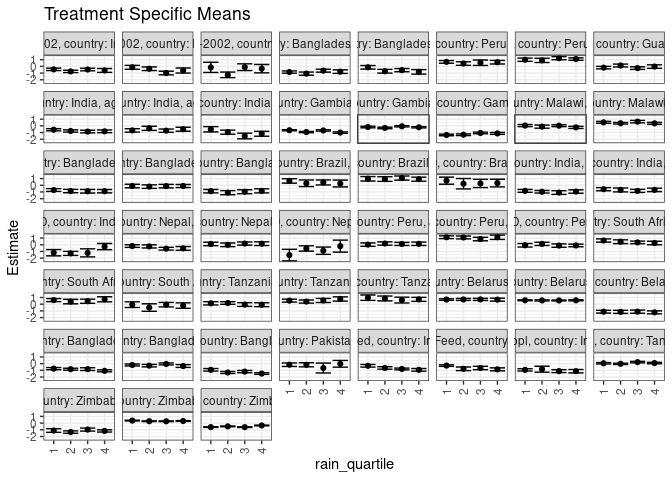

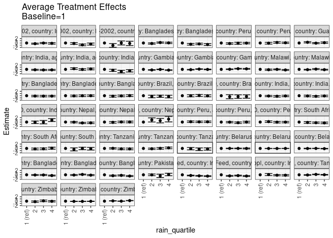

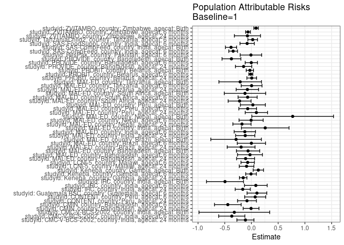

## Results Table

### Parameter: TSM

| studyid | country | agecat | intervention_level | baseline_level | estimate | ci_lower | ci_upper |
| --- | --- | --- | --- | --- | --- | --- | --- |
| CMC-V-BCS-2002 | India | Birth | 1 | NA | -0.1441176 | -0.9030320 | 0.6147967 |
| CMC-V-BCS-2002 | India | Birth | 2 | NA | -1.2631818 | -1.6787939 | -0.8475697 |
| CMC-V-BCS-2002 | India | Birth | 3 | NA | -0.1192857 | -0.6215639 | 0.3829924 |
| CMC-V-BCS-2002 | India | Birth | 4 | NA | -0.3365789 | -0.9594494 | 0.2862915 |
| CMC-V-BCS-2002 | India | 6 months | 1 | NA | -0.1346078 | -0.4241091 | 0.1548934 |
| CMC-V-BCS-2002 | India | 6 months | 2 | NA | -0.3524465 | -0.6228689 | -0.0820240 |
| CMC-V-BCS-2002 | India | 6 months | 3 | NA | -0.9886598 | -1.2587741 | -0.7185454 |
| CMC-V-BCS-2002 | India | 6 months | 4 | NA | -0.6156389 | -0.9908921 | -0.2403856 |
| CMC-V-BCS-2002 | India | 24 months | 1 | NA | -0.4441089 | -0.6265287 | -0.2616891 |
| CMC-V-BCS-2002 | India | 24 months | 2 | NA | -0.7511616 | -0.9235867 | -0.5787365 |
| CMC-V-BCS-2002 | India | 24 months | 3 | NA | -0.4676353 | -0.6615054 | -0.2737652 |
| CMC-V-BCS-2002 | India | 24 months | 4 | NA | -0.6059394 | -0.8953325 | -0.3165463 |
| CMIN | Bangladesh | 6 months | 1 | NA | -0.1356667 | -0.4008821 | 0.1295487 |
| CMIN | Bangladesh | 6 months | 2 | NA | -0.7236022 | -1.0053974 | -0.4418069 |
| CMIN | Bangladesh | 6 months | 3 | NA | -0.5592619 | -0.7980646 | -0.3204592 |
| CMIN | Bangladesh | 6 months | 4 | NA | -0.8142623 | -1.1495879 | -0.4789367 |
| CMIN | Bangladesh | 24 months | 1 | NA | -0.8462025 | -1.0110322 | -0.6813728 |
| CMIN | Bangladesh | 24 months | 2 | NA | -1.0795652 | -1.3177148 | -0.8414157 |
| CMIN | Bangladesh | 24 months | 3 | NA | -0.6369828 | -0.8582589 | -0.4157066 |
| CMIN | Bangladesh | 24 months | 4 | NA | -0.7871622 | -1.0533497 | -0.5209746 |
| CONTENT | Peru | 6 months | 1 | NA | 0.9944624 | 0.7512143 | 1.2377104 |
| CONTENT | Peru | 6 months | 2 | NA | 0.8994844 | 0.5792936 | 1.2196751 |
| CONTENT | Peru | 6 months | 3 | NA | 1.2257652 | 0.9877325 | 1.4637978 |
| CONTENT | Peru | 6 months | 4 | NA | 1.0971190 | 0.9193110 | 1.2749271 |
| CONTENT | Peru | 24 months | 1 | NA | 0.6738182 | 0.4748657 | 0.8727706 |
| CONTENT | Peru | 24 months | 2 | NA | 0.4274286 | 0.1646019 | 0.6902552 |
| CONTENT | Peru | 24 months | 3 | NA | 0.5505000 | 0.1447225 | 0.9562775 |
| CONTENT | Peru | 24 months | 4 | NA | 0.6253704 | 0.3576946 | 0.8930461 |
| Guatemala BSC | Guatemala | 6 months | 1 | NA | -0.1863611 | -0.3779725 | 0.0052503 |
| Guatemala BSC | Guatemala | 6 months | 2 | NA | 0.1297500 | -0.0854696 | 0.3449696 |

[output cut: 174 more lines]

### Parameter: E(Y)

| studyid | country | agecat | intervention_level | baseline_level | estimate | ci_lower | ci_upper |
| --- | --- | --- | --- | --- | --- | --- | --- |
| CMC-V-BCS-2002 | India | Birth | NA | NA | -0.4648256 | -0.7643210 | -0.1653302 |
| CMC-V-BCS-2002 | India | 6 months | NA | NA | -0.5026766 | -0.6536848 | -0.3516685 |
| CMC-V-BCS-2002 | India | 24 months | NA | NA | -0.5571505 | -0.6585247 | -0.4557763 |
| CMIN | Bangladesh | 6 months | NA | NA | -0.5780453 | -0.7226627 | -0.4334279 |
| CMIN | Bangladesh | 24 months | NA | NA | -0.8535391 | -0.9644236 | -0.7426546 |
| CONTENT | Peru | 6 months | NA | NA | 1.0644279 | 0.9468682 | 1.1819876 |
| CONTENT | Peru | 24 months | NA | NA | 0.5902439 | 0.4560143 | 0.7244735 |
| Guatemala BSC | Guatemala | 6 months | NA | NA | -0.0840134 | -0.1945572 | 0.0265305 |
| IRC | India | Birth | NA | NA | -1.0105831 | -1.1973019 | -0.8238643 |
| IRC | India | 6 months | NA | NA | -0.5989297 | -0.7344491 | -0.4634104 |
| IRC | India | 24 months | NA | NA | -0.7458150 | -0.8368180 | -0.6548120 |
| Keneba | Gambia | Birth | NA | NA | -1.2349454 | -1.2972413 | -1.1726496 |
| Keneba | Gambia | 6 months | NA | NA | -0.1846038 | -0.2354782 | -0.1337293 |
| Keneba | Gambia | 24 months | NA | NA | -0.8099290 | -0.8570608 | -0.7627972 |
| LCNI-5 | Malawi | 6 months | NA | NA | 0.4499404 | 0.3788501 | 0.5210308 |
| LCNI-5 | Malawi | 24 months | NA | NA | -0.0477709 | -0.1296526 | 0.0341109 |
| MAL-ED | Bangladesh | Birth | NA | NA | -0.9418605 | -1.0869834 | -0.7967375 |
| MAL-ED | Bangladesh | 6 months | NA | NA | -0.1376763 | -0.2664642 | -0.0088885 |
| MAL-ED | Bangladesh | 24 months | NA | NA | -0.8192925 | -0.9412667 | -0.6973182 |
| MAL-ED | Brazil | Birth | NA | NA | 0.4029032 | 0.0896793 | 0.7161272 |
| MAL-ED | Brazil | 6 months | NA | NA | 0.9720774 | 0.8078144 | 1.1363403 |
| MAL-ED | Brazil | 24 months | NA | NA | 0.4626233 | 0.2567495 | 0.6684971 |
| MAL-ED | India | Birth | NA | NA | -0.9324444 | -1.2067907 | -0.6580982 |
| MAL-ED | India | 6 months | NA | NA | -0.7047422 | -0.8301590 | -0.5793255 |
| MAL-ED | India | 24 months | NA | NA | -0.9516520 | -1.0670654 | -0.8362385 |
| MAL-ED | Nepal | Birth | NA | NA | -0.7684615 | -1.1257770 | -0.4111460 |
| MAL-ED | Nepal | 6 months | NA | NA | 0.1104308 | -0.0208643 | 0.2417259 |
| MAL-ED | Nepal | 24 months | NA | NA | -0.3749123 | -0.4886073 | -0.2612173 |
| MAL-ED | Peru | Birth | NA | NA | -0.0520175 | -0.1725298 | 0.0684947 |
| MAL-ED | Peru | 6 months | NA | NA | 1.0528816 | 0.9313005 | 1.1744626 |
| MAL-ED | Peru | 24 months | NA | NA | 0.1111982 | -0.0118399 | 0.2342362 |
| MAL-ED | South Africa | Birth | NA | NA | -0.1925833 | -0.4053570 | 0.0201904 |
| MAL-ED | South Africa | 6 months | NA | NA | 0.5421785 | 0.3900443 | 0.6943126 |
| MAL-ED | South Africa | 24 months | NA | NA | 0.4090301 | 0.2879441 | 0.5301161 |
| MAL-ED | Tanzania | Birth | NA | NA | 0.7624348 | 0.5710709 | 0.9537986 |
| MAL-ED | Tanzania | 6 months | NA | NA | 0.5362213 | 0.4049390 | 0.6675036 |
| MAL-ED | Tanzania | 24 months | NA | NA | 0.0547975 | -0.0703378 | 0.1799328 |
| PROBIT | Belarus | Birth | NA | NA | -1.1491782 | -1.3593933 | -0.9389630 |
| PROBIT | Belarus | 6 months | NA | NA | 0.5741099 | 0.5141290 | 0.6340908 |
| PROBIT | Belarus | 24 months | NA | NA | 0.6981406 | 0.5843775 | 0.8119038 |
| PROVIDE | Bangladesh | Birth | NA | NA | -1.2984586 | -1.3752758 | -1.2216415 |
| PROVIDE | Bangladesh | 6 months | NA | NA | -0.1990907 | -0.2817968 | -0.1163845 |
| PROVIDE | Bangladesh | 24 months | NA | NA | -0.8928670 | -0.9755153 | -0.8102187 |
| ResPak | Pakistan | 6 months | NA | NA | -0.1641841 | -0.3464247 | 0.0180565 |
| SAS-CompFeed | India | Birth | NA | NA | -0.6700453 | -0.8474950 | -0.4925957 |
| SAS-CompFeed | India | 6 months | NA | NA | -0.6657084 | -0.8024377 | -0.5289791 |
| SAS-FoodSuppl | India | 6 months | NA | NA | -1.0121579 | -1.1280429 | -0.8962729 |
| TanzaniaChild2 | Tanzania | 6 months | NA | NA | 0.0809332 | 0.0282644 | 0.1336020 |
| ZVITAMBO | Zimbabwe | Birth | NA | NA | -0.5151425 | -0.5409938 | -0.4892911 |
| ZVITAMBO | Zimbabwe | 6 months | NA | NA | 0.3105514 | 0.2848767 | 0.3362262 |
| ZVITAMBO | Zimbabwe | 24 months | NA | NA | -1.1825404 | -1.2814625 | -1.0836183 |

### Parameter: ATE

| studyid | country | agecat | intervention_level | baseline_level | estimate | ci_lower | ci_upper |
| --- | --- | --- | --- | --- | --- | --- | --- |
| CMC-V-BCS-2002 | India | Birth | 1 | 1 | 0.0000000 | 0.0000000 | 0.0000000 |
| CMC-V-BCS-2002 | India | Birth | 2 | 1 | -1.1190642 | -1.9843297 | -0.2537987 |
| CMC-V-BCS-2002 | India | Birth | 3 | 1 | 0.0248319 | -0.8852418 | 0.9349057 |
| CMC-V-BCS-2002 | India | Birth | 4 | 1 | -0.1924613 | -1.1742548 | 0.7893322 |
| CMC-V-BCS-2002 | India | 6 months | 1 | 1 | 0.0000000 | 0.0000000 | 0.0000000 |
| CMC-V-BCS-2002 | India | 6 months | 2 | 1 | -0.2178386 | -0.6139943 | 0.1783170 |
| CMC-V-BCS-2002 | India | 6 months | 3 | 1 | -0.8540520 | -1.2499973 | -0.4581066 |
| CMC-V-BCS-2002 | India | 6 months | 4 | 1 | -0.4810310 | -0.9549783 | -0.0070838 |
| CMC-V-BCS-2002 | India | 24 months | 1 | 1 | 0.0000000 | 0.0000000 | 0.0000000 |
| CMC-V-BCS-2002 | India | 24 months | 2 | 1 | -0.3070527 | -0.5580654 | -0.0560400 |
| CMC-V-BCS-2002 | India | 24 months | 3 | 1 | -0.0235264 | -0.2897267 | 0.2426739 |
| CMC-V-BCS-2002 | India | 24 months | 4 | 1 | -0.1618305 | -0.5039202 | 0.1802592 |
| CMIN | Bangladesh | 6 months | 1 | 1 | 0.0000000 | 0.0000000 | 0.0000000 |
| CMIN | Bangladesh | 6 months | 2 | 1 | -0.5879355 | -0.9749081 | -0.2009629 |
| CMIN | Bangladesh | 6 months | 3 | 1 | -0.4235952 | -0.7804789 | -0.0667116 |
| CMIN | Bangladesh | 6 months | 4 | 1 | -0.6785956 | -1.1061263 | -0.2510650 |
| CMIN | Bangladesh | 24 months | 1 | 1 | 0.0000000 | 0.0000000 | 0.0000000 |
| CMIN | Bangladesh | 24 months | 2 | 1 | -0.2333627 | -0.5229901 | 0.0562647 |
| CMIN | Bangladesh | 24 months | 3 | 1 | 0.2092198 | -0.0667004 | 0.4851400 |
| CMIN | Bangladesh | 24 months | 4 | 1 | 0.0590404 | -0.2540485 | 0.3721292 |
| CONTENT | Peru | 6 months | 1 | 1 | 0.0000000 | 0.0000000 | 0.0000000 |
| CONTENT | Peru | 6 months | 2 | 1 | -0.0949780 | -0.4970871 | 0.3071311 |
| CONTENT | Peru | 6 months | 3 | 1 | 0.2313028 | -0.1090340 | 0.5716396 |
| CONTENT | Peru | 6 months | 4 | 1 | 0.1026567 | -0.1986494 | 0.4039627 |
| CONTENT | Peru | 24 months | 1 | 1 | 0.0000000 | 0.0000000 | 0.0000000 |
| CONTENT | Peru | 24 months | 2 | 1 | -0.2463896 | -0.5760257 | 0.0832465 |
| CONTENT | Peru | 24 months | 3 | 1 | -0.1233182 | -0.5752446 | 0.3286082 |
| CONTENT | Peru | 24 months | 4 | 1 | -0.0484478 | -0.3819630 | 0.2850674 |
| Guatemala BSC | Guatemala | 6 months | 1 | 1 | 0.0000000 | 0.0000000 | 0.0000000 |
| Guatemala BSC | Guatemala | 6 months | 2 | 1 | 0.3161111 | 0.0279542 | 0.6042681 |

[output cut: 174 more lines]

### Parameter: PAR

| studyid | country | agecat | intervention_level | baseline_level | estimate | ci_lower | ci_upper |
| --- | --- | --- | --- | --- | --- | --- | --- |
| CMC-V-BCS-2002 | India | Birth | 1 | NA | -0.3207079 | -0.9824835 | 0.3410676 |
| CMC-V-BCS-2002 | India | 6 months | 1 | NA | -0.3680688 | -0.6133319 | -0.1228057 |
| CMC-V-BCS-2002 | India | 24 months | 1 | NA | -0.1130416 | -0.2726785 | 0.0465953 |
| CMIN | Bangladesh | 6 months | 1 | NA | -0.4423786 | -0.6919928 | -0.1927644 |
| CMIN | Bangladesh | 24 months | 1 | NA | -0.0073366 | -0.1549810 | 0.1403079 |
| CONTENT | Peru | 6 months | 1 | NA | 0.0699655 | -0.1271744 | 0.2671055 |
| CONTENT | Peru | 24 months | 1 | NA | -0.0835743 | -0.2597864 | 0.0926378 |
| Guatemala BSC | Guatemala | 6 months | 1 | NA | 0.1023477 | -0.0825841 | 0.2872796 |
| IRC | India | Birth | 1 | NA | -0.4954549 | -0.8414401 | -0.1494696 |
| IRC | India | 6 months | 1 | NA | 0.0815688 | -0.1313694 | 0.2945070 |
| IRC | India | 24 months | 1 | NA | -0.1631249 | -0.3043543 | -0.0218955 |
| Keneba | Gambia | Birth | 1 | NA | 0.1286226 | 0.0321301 | 0.2251151 |
| Keneba | Gambia | 6 months | 1 | NA | -0.0084183 | -0.1078911 | 0.0910546 |
| Keneba | Gambia | 24 months | 1 | NA | -0.1548029 | -0.2251428 | -0.0844631 |
| LCNI-5 | Malawi | 6 months | 1 | NA | -0.0710400 | -0.1965912 | 0.0545112 |
| LCNI-5 | Malawi | 24 months | 1 | NA | -0.0912881 | -0.2276260 | 0.0450497 |
| MAL-ED | Bangladesh | Birth | 1 | NA | -0.0633448 | -0.2813789 | 0.1546893 |
| MAL-ED | Bangladesh | 6 months | 1 | NA | -0.0282824 | -0.2613936 | 0.2048287 |
| MAL-ED | Bangladesh | 24 months | 1 | NA | -0.1093609 | -0.2778508 | 0.0591289 |
| MAL-ED | Brazil | Birth | 1 | NA | -0.2876850 | -0.7609060 | 0.1855360 |
| MAL-ED | Brazil | 6 months | 1 | NA | -0.0011779 | -0.2656879 | 0.2633322 |
| MAL-ED | Brazil | 24 months | 1 | NA | -0.1933767 | -0.4539510 | 0.0671976 |
| MAL-ED | India | Birth | 1 | NA | 0.2575556 | -0.1880982 | 0.7032093 |
| MAL-ED | India | 6 months | 1 | NA | -0.1241993 | -0.3236879 | 0.0752893 |
| MAL-ED | India | 24 months | 1 | NA | -0.1164981 | -0.2958653 | 0.0628691 |
| MAL-ED | Nepal | Birth | 1 | NA | 0.7715385 | 0.0068006 | 1.5362763 |
| MAL-ED | Nepal | 6 months | 1 | NA | -0.0063470 | -0.2319754 | 0.2192814 |
| MAL-ED | Nepal | 24 months | 1 | NA | -0.1775638 | -0.3477080 | -0.0074196 |
| MAL-ED | Peru | Birth | 1 | NA | 0.0265539 | -0.2076826 | 0.2607904 |
| MAL-ED | Peru | 6 months | 1 | NA | -0.0704344 | -0.2363423 | 0.0954734 |
| MAL-ED | Peru | 24 months | 1 | NA | 0.0920770 | -0.1168103 | 0.3009642 |
| MAL-ED | South Africa | Birth | 1 | NA | -0.1209833 | -0.5082147 | 0.2662480 |
| MAL-ED | South Africa | 6 months | 1 | NA | -0.0715637 | -0.2502594 | 0.1071320 |
| MAL-ED | South Africa | 24 months | 1 | NA | -0.2219699 | -0.4366807 | -0.0072591 |
| MAL-ED | Tanzania | Birth | 1 | NA | -0.2111366 | -0.6094605 | 0.1871872 |
| MAL-ED | Tanzania | 6 months | 1 | NA | 0.0028410 | -0.1915153 | 0.1971974 |
| MAL-ED | Tanzania | 24 months | 1 | NA | -0.0763632 | -0.2860236 | 0.1332972 |
| PROBIT | Belarus | Birth | 1 | NA | -0.0294944 | -0.0978185 | 0.0388297 |
| PROBIT | Belarus | 6 months | 1 | NA | -0.0121321 | -0.0491531 | 0.0248888 |
| PROBIT | Belarus | 24 months | 1 | NA | 0.0051984 | -0.0852253 | 0.0956220 |
| PROVIDE | Bangladesh | Birth | 1 | NA | -0.3748689 | -0.5514617 | -0.1982761 |
| PROVIDE | Bangladesh | 6 months | 1 | NA | -0.0029295 | -0.1173779 | 0.1115189 |
| PROVIDE | Bangladesh | 24 months | 1 | NA | -0.1471094 | -0.2999036 | 0.0056848 |
| ResPak | Pakistan | 6 months | 1 | NA | -0.0096825 | -0.2103378 | 0.1909727 |
| SAS-CompFeed | India | Birth | 1 | NA | -0.3819501 | -0.4867343 | -0.2771658 |
| SAS-CompFeed | India | 6 months | 1 | NA | -0.3426284 | -0.4240909 | -0.2611659 |
| SAS-FoodSuppl | India | 6 months | 1 | NA | -0.0808454 | -0.2148958 | 0.0532050 |
| TanzaniaChild2 | Tanzania | 6 months | 1 | NA | 0.0234396 | -0.0664575 | 0.1133368 |
| ZVITAMBO | Zimbabwe | Birth | 1 | NA | 0.0865964 | 0.0446038 | 0.1285890 |
| ZVITAMBO | Zimbabwe | 6 months | 1 | NA | -0.0651736 | -0.1105132 | -0.0198340 |
| ZVITAMBO | Zimbabwe | 24 months | 1 | NA | -0.0755707 | -0.3200186 | 0.1688772 |